# Clustering spatial transcriptomics data

Data Lab for ALSF

2026

## Objectives

- Perform dimensionality reduction (PCA and UMAP) and graph-based clustering on Visium data
- Use the `Banksy` package to perform spatially-aware dimensionality reduction and clustering
- Compare clusters calculated with and without spatial information

## Introduction

In this notebook, we’ll cluster expression data from a mouse sample with osteosarcoma lung metastases from [Reinecke et al. (2025)](https://doi.org/10.1158/1078-0432.CCR-24-0049). This sample was processed using second-generation Visium technology and quantified with `Space Ranger 2.1.1`. We have already processed this dataset for you, including filtering out low quality spots (`SpotSweeper` removed 20 low-quality spots) and normalization, which you can see in this notebook: https://github.com/AlexsLemonade/training-modules/blob/master/spatial/setup/osteo/prepare-osteo-data.Rmd.

As we have discussed, Visium spatial transcriptomics data does not quantify expression at the single-cell level, but rather each Visium spot captures the combined expression of 1-10 cells. This means that when we perform clustering on Visium data, we are actually clustering spots with similar transcriptional profiles, not individual cells.

Also unlike single-cell data, we now have an additional consideration of spatial information. In many cases (but not all!), it’s reasonable to assume that nearby spots will tend to have more similar expression to one another than to distant spots. We can therefore incorporate each spot’s physical position in the tissue alongside its expression profile during clustering, which may help to approximate spatial domains.

In this notebook, we’ll explore complementary approaches: first running expression-based dimensionality reduction and clustering just as we would for single-cell data, and then performing the same analyses using the [`Banksy` package](https://bioconductor.org/packages/release/bioc/html/Banksy.html). `Banksy` (sometimes also stylized as `BANKSY`) offers a spatially-aware dimensionality reduction and clustering approach that augments each spot’s expression with information from its spatial neighborhood.

## Set up

To begin, we’ll load the packages we’ll use throughout this notebook.

```r
# The main class we use for spatial transcriptomic data
suppressPackageStartupMessages({
  library(SpatialExperiment)
})
# To support plotting
library(ggplot2)
library(patchwork)

# Set ggplot2 theme
theme_set(theme_bw())
```

We’ll set a seed for reproducibility, since we’ll be running UMAP and clustering.

```r
set.seed(2026)
```

### Directories and files

The pre-processed SPE object for this sample is stored in a sample-specific subdirectory of `data/osteo`, organized by GEO sample ID.

```r
# define sample id we'll be analyzing
sample_id <- "GSM8478586"

# data directory for this sample
data_dir <- file.path("data/osteo", sample_id, "normalized")

normalized_rds <- file.path(data_dir, "osteo_normalized_spe.rds")
```

We’ll also define the path for outputting clusters. To save space, we’ll conclude by exporting a TSV with the clusters we calculate in this notebook (along with other per-spot metadata).

```r
# define a results directory for this sample and create it if it doesn't exist
results_dir <- file.path("results/osteo", sample_id)
fs::dir_create(results_dir)

cluster_tsv <- file.path(results_dir, "osteo_clusters.tsv")
```

## Import

Let’s start by reading in the pre-processed SPE object:

```r
spe <- readr::read_rds(normalized_rds)
```

Before working with this SPE, let’s get familiar with it. We’ll first print the SPE to review its contents, including the number of spots and genes and what assays are available.

```r
# print the spe
spe
```

```
class: SpatialExperiment
dim: 19465 1632
metadata(0):
assays(2): counts logcounts
rownames(19465): ENSMUSG00000051951 ENSMUSG00000025900 ...
  ENSMUSG00000096520 ENSMUSG00000096686
rowData names(3): ID Symbol Type
colnames(1632): AACACCTAAGCATTGC-1 AACAGGCCATTGTCAC-1 ...
  TGTTCGTGGCGTCGTG-1 TGTTGGTGCGGAATCA-1
colData names(16): barcode in_tissue ... local_outliers sizeFactor
reducedDimNames(0):
mainExpName: NULL
altExpNames(0):
spatialCoords names(2) : pxl_col_in_fullres pxl_row_in_fullres
imgData names(4): sample_id image_id data scaleFactor
```

We’ll also create a plot of the H&E image to orient ourselves to the tissue before diving into clustering, adjusting the styling of the plot to our preferences. We’ll refer back to it throughout the notebook to help interpret the spatial patterns we find.

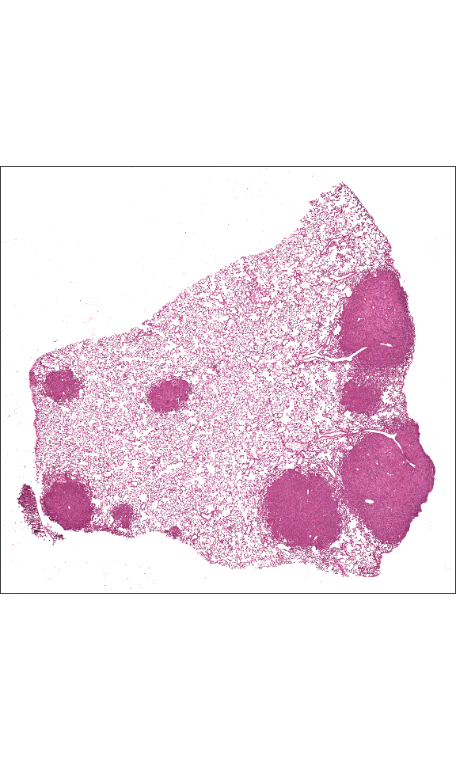

```r
# define H&E plot for general use in notebook
he_plot <- ggspavis::plotVisium(spe, spots = FALSE, zoom = TRUE) +
  # add styling to match other panels
  theme(
    plot.title = ggplot2::element_text(
      hjust = 0.5,
      margin = ggplot2::margin(0, 0, 0.1, 0)
    ),
    panel.border = ggplot2::element_rect(color = "black", linewidth = 0.3)
  )

he_plot
```

This image clearly shows regions of tumor cells amid the lung parenchyma, which appears less dense because of the lung’s alveolar spaces.

Let’s also get a sense of the RNA counts here by plotting some of the QC statistics that were calculated for you, including the total UMIs (`sum`) and number of unique detected genes (`detected`). Note that these plots use an upper limit on the color scale to be able to see lower value spots more clearly.

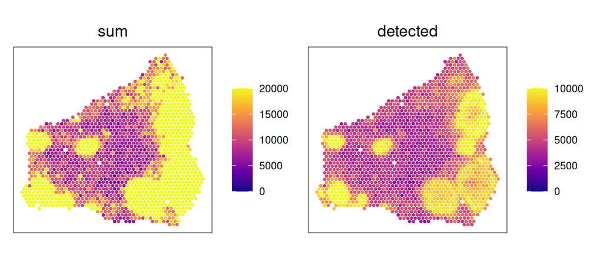

```r
total_plot <- ggspavis::plotCoords(spe, annotate = "sum", point_size = 1) +
  scale_color_viridis_c(
    # cap scale at 20,000; all value above this will be shown as 20,000
    limits = c(0, 20000),
    # tell the scales to "squish" to the limit specified above, where
    # oob stands for "out of bounds" handling
    oob = scales::oob_squish,
    # fun with color scales!
    option = "plasma"
  )
detected_plot <- ggspavis::plotCoords(
  spe,
  annotate = "detected",
  point_size = 1
) +
  scale_color_viridis_c(
    # cap scale at 10,000
    limits = c(0, 10000),
    oob = scales::oob_squish,
    option = "plasma"
  )
total_plot + detected_plot
```

There is clearly more RNA expression in the tumor regions than in the parenchyma, which makes sense biologically. Tumor cells are highly proliferative and transcriptionally active. In addition, the lower density of parenchymal tissue makes for fewer cells per spot, and less overall expression.

This plot also illustrates why local QC filtering thresholds are preferable to global ones for heterogeneous tissue samples like this. Specifically, the parenchymal spots have lower UMI and gene counts not because they are low quality, but because of the alveolar architecture of lung tissue itself. A global threshold would not distinguish between a genuinely low-quality spot and a spot that overlies sparse tissue, and would have ended up preferentially removing parenchymal spots. For a Visium experiment, we want to retain much of the spatial context, including the contrast between tumor and parenchymal regions, and using local QC thresholds allows us to do so.

## Dimension reduction and clustering

The first clustering analysis we’ll perform will look analogous to single-cell post-processing. After that, we’ll compare to clustering with the `Banksy` approach to see how including spatial information influences cluster detection.

### Expression-only analysis

In this section, we’ll apply the same dimensionality reduction and clustering workflow we would use for single-cell data, treating each spot’s expression profile as the unit of analysis without any spatial information. This serves as a useful baseline for comparison when we later apply a spatially-aware approach.

Again, remember that we are working at the spot level. This means clusters will represent groups of similar spots, each of which may include multiple nearby cells.

When calculating PCA, we often prefer to reduce the number of genes to only the most highly variable ones, which will both speed up calculations and ensure stronger signal. To do this, we’ll start by modeling per-gene expression variance with `scran::modelGeneVar()`, which separates each gene’s variation into biological and technical components, using the observed relationship between mean expression and technical variation. We’ll then use these modeling results to select the 2000 genes with the highest biological variation (these are our high-variance genes, aka HVGs). Finally, we’ll perform PCA that considers just these genes with `scater::runPCA()`.

```r
# model gene variance
gene_variance <- scran::modelGeneVar(spe)

# calculate the top 2000 HVGs
hvg_vector <- scran::getTopHVGs(gene_variance, n = 2000)

# calculate PCE using the top HVGs, saving back to the SPE object
spe <- scater::runPCA(spe, subset_row = hvg_vector)
```

Next, we will perform graph-based clustering using `scran::clusterCells()`, which calculates clusters using the `bluster` package under the hood.

We’ll use Jaccard weighting and the Louvain algorithm, specifying `k = 20` nearest neighbors. We’ll also save these clustering parameters as `cluster_params` so we can reuse the same settings when running spatially-aware clustering later.

But first, one caveat: it’s worth noting that the choice of `k` and clustering algorithm are important analytical decisions (as well as other parameters like `resolution`, which we are leaving at its default value of 1 here). In your own research, we do recommend taking some time to explore parameter space when clustering, which you can learn more about in the the `scRNA-seq-advanced` training module’s clustering evaluation exercise.

```r
# define clustering parameters
cluster_params <- bluster::NNGraphParam(
  k = 20,
  cluster.fun = "louvain",
  type = "jaccard"
)

# perform clustering and save to SPE colData
colData(spe)$cluster_nonspatial <- scran::clusterCells(
  spe,
  use.dimred = "PCA",
  BLUSPARAM = cluster_params
)
```

We’ll also calculate a UMAP for visualization using `scater::runUMAP()`.

```r
spe <- scater::runUMAP(spe)
```

Let’s visualize our results so far by plotting the UMAP and spatial coordinate plots, each colored by cluster with the same color palette. We’ll also include the H&E image for reference.

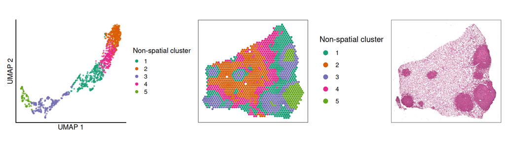

```r
# define UMAP plot
umap_nonspatial <- scater::plotUMAP(
  spe,
  color_by = "cluster_nonspatial",
  point_size = 0.5
) +
  # set custom palette and legend title
  scale_color_brewer(
    name = "Non-spatial cluster",
    palette = "Dark2"
  ) +
  # ensure more visible points in legend
  guides(
    color = guide_legend(override.aes = list(alpha = 1, size = 1.5))
  ) +
  # remove axis scales from umap plot
  theme(
    axis.text = element_blank(),
    axis.ticks = element_blank()
  )

# define coordinates plot
coords_nonspatial <- ggspavis::plotCoords(
  spe,
  annotate = "cluster_nonspatial",
  point_size = 1
) +
  # set custom palette and legend title
  scale_color_brewer(
    name = "Non-spatial cluster",
    palette = "Dark2"
  )

# combine plots with patchwork
umap_nonspatial + coords_nonspatial + he_plot
```

This has resulted in five clusters. How do you think these compare to regions in the H&E? What patterns do you see, for example between tumor and parenchymal regions?

### Spatially-aware clustering with Banksy

[`Banksy`](https://prabhakarlab.github.io/Banksy/) ([Singhal *et al.* 2024](https://doi.org/10.1038/s41588-024-01664-3)) is a package for spatially-aware dimensionality reduction and clustering. These spatially-aware clusters can also serve as a first step towards tissue domain identification.

This method rests on the assumption that spots in the same tissue domain tend not only to share similar expression profiles, but also tend to be surrounded by spots with similar expression. In other words, nearby spots are likely to be transcriptionally similar. `Banksy` leverages this insight by incorporating neighborhood information into the PCA itself. Performing clustering on this spatially-aware PCA allows `Banksy` to identify clusters with both distinct expression and tissue domain structure.

The `Banksy` algorithm works in three steps:

1. **Compute the `Banksy` matrix** with `Banksy::computeBanksy()`.

For each spot, `Banksy::computeBanksy()` averages expression across its `k_geom` nearest spatial neighbors to create a neighborhood expression profile, stored as the `H0` assay. Optionally, `Banksy::computeBanksy()` can also compute an Azimuthal Gabor Filter (AGF), which captures directional expression gradients that can help resolve finer structure at domain boundaries. When AGF is turned on, a second `Banksy` matrix is stored as the `H1` assay (the `0` and `1` in these assay names indicate if AGF is off or on, respectively).

2. **Run `Banksy` PCA** with `Banksy::runBanksyPCA()`.

`Banksy::runBanksyPCA()` first creates a single matrix that is a weighted combination of the normalized expression in `logcounts` and the `Banksy` neighborhood matrix (`H0` or `H0` and `H1` if AGF is on). To combine these matrices, `Banksy` introduces the `lambda` parameter. `lambda` ranges from 0 – 1 and controls how much weight is given to the `Banksy` neighborhood information matrix relative to `logcounts` expression, where a value of 0 considers only `logcounts` expression. The `Banksy` authors recommend a value of `lambda = 0.2` for Visium spot data, as described in [this `Banksy` vignette on parameter selection](https://prabhakarlab.github.io/Banksy/articles/parameter-selection.html#parameters).

`Banksy` then performs PCA using this combined matrix as the input.

3. **Perform graph-based clustering**.

Once the PCA is calculated, it can be used for a variety of downstream tasks, including clustering and UMAP calculation. In this notebook, we’ll use `scran` and `scater` tools for these steps, but we will also point out that `Banksy` includes wrapper functions for these calculations, which can be useful if you are evaluating multiple `Banksy` parameters at once.

In this notebook, we’ll run `Banksy` in two configurations — without AGF and with AGF — and compare the results.

Before we get started, we have to modify our SPE object. When calculating the spatially-aware matrix and the PCA, `Banksy` uses all genes present in the SPE; it does not subset to only the most variable genes. To ensure a fair comparison between clustering approaches, we will subset the SPE to the HVGs that we identified before running `Banksy` and save it to a new variable `hvg_spe`. We’ll use this SPE object for the rest of the notebook.

```r
# subset the SPE to contain only HVGs
hvg_spe <- spe[hvg_vector, ]
```

#### Running Banksy without AGF

We’ll start by computing the `Banksy` matrix without AGF. As noted above, `lambda = 0.2` is a commonly used starting point for Visium spot data; this value means roughly 80% of the signal in the combined matrix comes from each spot’s own expression and 20% comes from its neighborhood. We’ll use `k_geom = 18` spatial neighbors for the neighborhood averaging, which is also the recommended starting point for Visium spot data.

```r
# define parameters recommended for Visium
lambda <- 0.2
k_geom <- 18

# calculate the Banksy matrix without AGF
hvg_spe <- Banksy::computeBanksy(
  hvg_spe,
  assay_name = "logcounts",
  k_geom = k_geom
)
```

```
Computing neighbors...
```

```
Spatial mode is kNN_median
```

```
Parameters: k_geom=18
```

```
Done
```

```
Done
```

```r
# show the SPE
hvg_spe
```

```
class: SpatialExperiment
dim: 2000 1632
metadata(1): BANKSY_params
assays(3): counts logcounts H0
rownames(2000): ENSMUSG00000003477 ENSMUSG00000069917 ...
  ENSMUSG00000042359 ENSMUSG00000022893
rowData names(3): ID Symbol Type
colnames(1632): AACACCTAAGCATTGC-1 AACAGGCCATTGTCAC-1 ...
  TGTTCGTGGCGTCGTG-1 TGTTGGTGCGGAATCA-1
colData names(17): barcode in_tissue ... sizeFactor cluster_nonspatial
reducedDimNames(2): PCA UMAP
mainExpName: NULL
altExpNames(0):
spatialCoords names(2) : pxl_col_in_fullres pxl_row_in_fullres
imgData names(4): sample_id image_id data scaleFactor
```

Notice we now have only 2000 genes, which is because we are using the HVG subset for the `Banksy` calculations.

We also see that a new `H0` assay has been added to the SPE, representing the neighborhood-averaged spot expression. Each entry represents the average expression of a given gene across the spatial neighbors of a given spot, rather than the spot’s own expression.

```r
assay(hvg_spe, "H0")[1:5, 1:5]
```

```
                   AACACCTAAGCATTGC-1 AACAGGCCATTGTCAC-1 AACAGTATCCGCCTGG-1
ENSMUSG00000003477          4.4523541         6.04729123           2.527428
ENSMUSG00000069917          5.3770596         5.13608501           3.338340
ENSMUSG00000001506          5.2622879         3.86334808           6.046223
ENSMUSG00000024140          4.5322147         6.46674641           2.960462
ENSMUSG00000026069          0.4947847         0.08612256           2.821459
                   AACATACTCCACAGTT-1 AACATAGGTTGGCACC-1
ENSMUSG00000003477           6.025411           5.380015
ENSMUSG00000069917           4.954438           6.406010
ENSMUSG00000001506           3.905922           4.819063
ENSMUSG00000024140           6.104644           6.254811
ENSMUSG00000026069           0.000000           1.060340
```

`Banksy::computeBanksy()` also stores the parameters it used in the SPE’s `metadata` slot, which is useful for keeping track of settings across runs:

```r
# show the SPE metadata
metadata(hvg_spe)$BANKSY_params
```

```
$assay_name
[1] "logcounts"

$M
[1] 0

$k_geom
[1] 18

$spatial_mode
[1] "kNN_median"
```

```
logcounts
```

```
kNN_median
```

Now, we can use `Banksy::runBanksyPCA()`, which combines `logcounts` and `H0` into a single matrix weighted by `lambda` and then runs PCA on it.

```r
# calculate PCA within Banksy
hvg_spe <- Banksy::runBanksyPCA(hvg_spe, lambda = lambda)

# show the SPE
hvg_spe
```

```
class: SpatialExperiment
dim: 2000 1632
metadata(1): BANKSY_params
assays(3): counts logcounts H0
rownames(2000): ENSMUSG00000003477 ENSMUSG00000069917 ...
  ENSMUSG00000042359 ENSMUSG00000022893
rowData names(3): ID Symbol Type
colnames(1632): AACACCTAAGCATTGC-1 AACAGGCCATTGTCAC-1 ...
  TGTTCGTGGCGTCGTG-1 TGTTGGTGCGGAATCA-1
colData names(17): barcode in_tissue ... sizeFactor cluster_nonspatial
reducedDimNames(3): PCA UMAP PCA_M0_lam0.2
mainExpName: NULL
altExpNames(0):
spatialCoords names(2) : pxl_col_in_fullres pxl_row_in_fullres
imgData names(4): sample_id image_id data scaleFactor
```

The new PCA that `Banksy` has calculated is named `PCA_M0_lam0.2`: `M0` indicates that AGF was not used, and `lam0.2` records the `lambda` value. `Banksy` generates these names automatically, making it easy to track different reduced dimension calculations when comparing multiple runs.

To keep the workflow consistent with what we did above, we’ll use `scater` and `scran` directly for calculating UMAPs, plotting, and clustering. We’ll also reuse the same `cluster_params` object defined earlier when we performed non-spatial clustering to ensure a direct comparison.

```r
# define PCA and UMAP names for bookkeeping
pca_name <- "PCA_M0_lam0.2"
umap_name <- "UMAP_banksy_nonagf"

# calculate UMAP
hvg_spe <- scater::runUMAP(
  hvg_spe,
  dimred = pca_name,
  name = umap_name
)

# perform clustering
colData(hvg_spe)$cluster_banksy_nonagf <- scran::clusterCells(
  hvg_spe,
  use.dimred = pca_name,
  BLUSPARAM = cluster_params
)
```

Let’s visualize this initial set of `Banksy` clusters alongside the H&E, just as we did for the expression-only results.

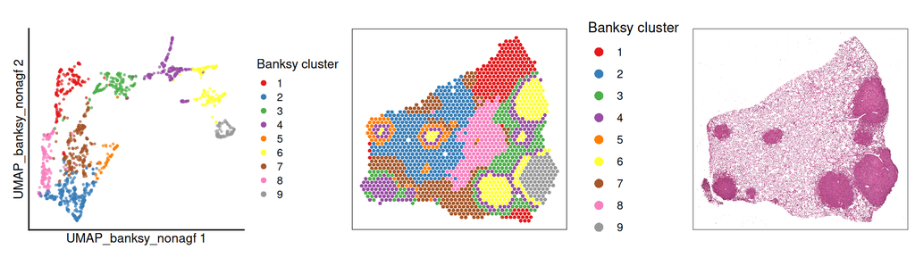

```r
# define UMAP plot
umap_banksky_nonagf <- scater::plotReducedDim(
  hvg_spe,
  dimred = umap_name,
  color_by = "cluster_banksy_nonagf",
  point_size = 0.5
) +
  # set custom palette and legend title
  scale_color_brewer(
    name = "Banksy cluster",
    palette = "Set1"
  ) +
  # ensure more visible points in legend
  guides(
    color = guide_legend(override.aes = list(alpha = 1, size = 1.5))
  ) +
  # remove axis scales from umap plot
  theme(
    axis.text = element_blank(),
    axis.ticks = element_blank()
  )

# define coordinates plot
coords_banksky_nonagf <- ggspavis::plotCoords(
  hvg_spe,
  annotate = "cluster_banksy_nonagf",
  point_size = 1
) +
  # set custom palette and legend title
  scale_color_brewer(
    name = "Banksy cluster",
    palette = "Set1"
  )

# combine plots using patchwork
umap_banksky_nonagf + coords_banksky_nonagf + he_plot
```

How do these clusters compare to the expression-only results? What differences do you see between these results, both in terms of the UMAP and the coordinates plot?

#### Running Banksy with AGF

Now we’ll re-run `Banksy::computeBanksy()` with AGF enabled (`compute_agf = TRUE`). As introduced above, AGF captures directional expression gradients and can help `Banksy` detect finer spatial structure at the boundaries between tissue domains.

When AGF is enabled, `k_geom` takes a vector of two values rather than a single one. The first value is used for the neighborhood averaging step, as before. The second value, which is usually larger, provides the broader spatial context needed for the AGF gradient calculation.

As suggested in the `Banksy` documentation, we’ll use `k_geom = c(18, 30)` for Visium spot data: 18 spots will be used for the neighborhood averaging and 30 spots will be used for the AGF calculation.

```r
# specify 18 neighbors for neighbor averaging, and 30 neighbors for AGF
k_geom <- c(18, 30)

# turn on compute_agf
hvg_spe <- Banksy::computeBanksy(
  hvg_spe,
  assay_name = "logcounts",
  compute_agf = TRUE,
  k_geom = k_geom
)
```

```
Computing neighbors...
```

```
Spatial mode is kNN_median
```

```
Parameters: k_geom=18
```

```
Done
```

```
Computing neighbors...
```

```
Spatial mode is kNN_median
```

```
Parameters: k_geom=30
```

```
Done
```

```
Done
```

```
Centering
```

```
Done
```

```r
# show the SPE
hvg_spe
```

```
class: SpatialExperiment
dim: 2000 1632
metadata(1): BANKSY_params
assays(4): counts logcounts H0 H1
rownames(2000): ENSMUSG00000003477 ENSMUSG00000069917 ...
  ENSMUSG00000042359 ENSMUSG00000022893
rowData names(3): ID Symbol Type
colnames(1632): AACACCTAAGCATTGC-1 AACAGGCCATTGTCAC-1 ...
  TGTTCGTGGCGTCGTG-1 TGTTGGTGCGGAATCA-1
colData names(18): barcode in_tissue ... cluster_nonspatial
  cluster_banksy_nonagf
reducedDimNames(4): PCA UMAP PCA_M0_lam0.2 UMAP_banksy_nonagf
mainExpName: NULL
altExpNames(0):
spatialCoords names(2) : pxl_col_in_fullres pxl_row_in_fullres
imgData names(4): sample_id image_id data scaleFactor
```

The SPE now contains an additional assay, `H1`, which stores the AGF-based neighborhood expression profile. Note that if you re-run `Banksy::computeBanksy()` with different parameters, the new object will only include the new `H0` and `H1`, as well the `BANKSY_params` entry from that run. We are saving back to the existing variable, so we are losing our previous results.

If you want to preserve results from multiple runs, you will need to keep this in mind and store each set of results separately.

```r
assay(hvg_spe, "H1")[1:5, 1:5]
```

```
                   AACACCTAAGCATTGC-1 AACAGGCCATTGTCAC-1 AACAGTATCCGCCTGG-1
ENSMUSG00000003477          0.3929694         0.14418156          0.8475595
ENSMUSG00000069917          0.1544137         0.30912427          1.0868996
ENSMUSG00000001506          0.3716754         0.17196694          0.6963811
ENSMUSG00000024140          0.2991111         0.03999879          0.8576865
ENSMUSG00000026069          0.3951272         0.12042702          1.3224681
                   AACATACTCCACAGTT-1 AACATAGGTTGGCACC-1
ENSMUSG00000003477         0.05983354         0.27039326
ENSMUSG00000069917         0.38020416         0.17541982
ENSMUSG00000001506         0.19555792         0.07417087
ENSMUSG00000024140         0.13477870         0.32895170
ENSMUSG00000026069         0.03422591         0.33066449
```

As with the non-AGF run, `Banksy::computeBanksy()` updated the `BANKSY_params` entry in the SPE’s `metadata` slot to reflect the new settings:

```r
metadata(hvg_spe)$BANKSY_params
```

```
$assay_name
[1] "logcounts"

$M
[1] 0 1

$k_geom
[1] 18 30

$spatial_mode
[1] "kNN_median"
```

```
logcounts
```

```
kNN_median
```

Now we can run `Banksy::runBanksyPCA()` with `use_agf = TRUE`. With this argument, the function concatenates `H0` and `H1` when constructing the combined expression-plus-neighborhood matrix that will be input to PCA.

```r
# use_agf tells Banksy to incorporate both the H0 and H1 assays, as well as logcounts expression
hvg_spe <- Banksy::runBanksyPCA(hvg_spe, lambda = lambda, use_agf = TRUE)

# show the SPE
hvg_spe
```

```
class: SpatialExperiment
dim: 2000 1632
metadata(1): BANKSY_params
assays(4): counts logcounts H0 H1
rownames(2000): ENSMUSG00000003477 ENSMUSG00000069917 ...
  ENSMUSG00000042359 ENSMUSG00000022893
rowData names(3): ID Symbol Type
colnames(1632): AACACCTAAGCATTGC-1 AACAGGCCATTGTCAC-1 ...
  TGTTCGTGGCGTCGTG-1 TGTTGGTGCGGAATCA-1
colData names(18): barcode in_tissue ... cluster_nonspatial
  cluster_banksy_nonagf
reducedDimNames(5): PCA UMAP PCA_M0_lam0.2 UMAP_banksy_nonagf
  PCA_M1_lam0.2
mainExpName: NULL
altExpNames(0):
spatialCoords names(2) : pxl_col_in_fullres pxl_row_in_fullres
imgData names(4): sample_id image_id data scaleFactor
```

The new PCA is named `PCA_M1_lam0.2`, where `M1` indicates that AGF was used (compared to `M0` from the without-AGF run), and `lam0.2` records the `lambda` value. We’ll now proceed to calculate the UMAP embeddings and clusters using the same `cluster_params` that we have been using previously.

```r
# define reducedDim names
pca_name <- "PCA_M1_lam0.2"
umap_name <- "UMAP_banksy_agf"

# Calculate UMAP
hvg_spe <- scater::runUMAP(
  hvg_spe,
  dimred = pca_name,
  name = umap_name
)

# Perform clustering
colData(hvg_spe)$cluster_banksy_agf <- scran::clusterCells(
  hvg_spe,
  use.dimred = pca_name,
  BLUSPARAM = cluster_params
)
```

Now let’s visualize all three sets of results side-by-side: expression-only, Banksy without AGF, and Banksy with AGF.

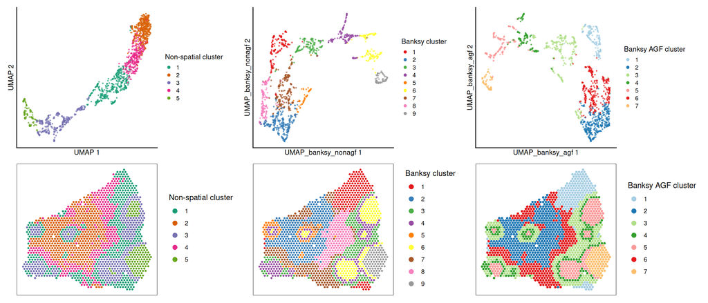

```r
umap_banksky_agf <- scater::plotReducedDim(
  hvg_spe,
  dimred = umap_name,
  color_by = "cluster_banksy_agf",
  point_size = 0.5
) +
  # set custom palette and legend title
  scale_color_brewer(
    name = "Banksy AGF cluster",
    palette = "Paired"
  ) +
  # ensure more visible points in legend
  guides(
    color = guide_legend(override.aes = list(alpha = 1, size = 1.5))
  ) +
  # remove axis scales from umap plot
  theme(
    axis.text = element_blank(),
    axis.ticks = element_blank()
  )

coords_banksky_agf <- ggspavis::plotCoords(
  hvg_spe,
  annotate = "cluster_banksy_agf",
  point_size = 1.25
) +
  # set custom palette and legend title
  scale_color_brewer(
    name = "Banksy AGF cluster",
    palette = "Paired"
  )

# Compile plots for display with patchwork
plot_list <- list(
  umap_nonspatial,
  umap_banksky_nonagf,
  umap_banksky_agf,
  coords_nonspatial,
  coords_banksky_nonagf,
  coords_banksky_agf
)

wrap_plots(plot_list, nrow = 2)
```

What differences do you see between `Banksy` clusters with and without AGF? Do you think AGF captured boundaries more cleanly as advertised? Next, how do the spatially-informed clusters overall compare to non-spatial clusters?